# Risk Factor Analysis

## Outcome Variable

**Outcome Variable:** dead

## Predictor Variables

**Intervention Variable:** ever_stunted06

**Adjustment Set:**

- sex
- arm
- enstunt
- month
- brthmon
- vagbrth
- impfloor
- earlybf
- hhwealth_quart
- W_birthwt
- W_birthlen
- W_mage
- W_mhtcm
- W_meducyrs
- W_feducyrs
- W_nrooms
- W_nchldlt5
- W_parity
- impsan
- safeh20
- predexfd6
- delta_month
- delta_brthmon
- delta_vagbrth
- delta_impfloor
- delta_earlybf
- delta_hhwealth_quart
- delta_W_birthwt
- delta_W_birthlen
- delta_W_mage
- delta_W_mhtcm
- delta_W_meducyrs
- delta_W_feducyrs
- delta_W_nrooms
- delta_W_nchldlt5
- delta_W_parity
- delta_impsan
- delta_safeh20
- delta_predexfd6

## Stratifying Variables

The analysis was stratified on these variable(s):

- studyid
- country

## Data Summary

| studyid | country | ever_stunted06 | dead | n_cell | n |
| --- | --- | --- | --- | --- | --- |
| ki0047075b-MAL-ED | BANGLADESH | 0 | 0 | 167 | 265 |
| ki0047075b-MAL-ED | BANGLADESH | 0 | 1 | 0 | 265 |
| ki0047075b-MAL-ED | BANGLADESH | 1 | 0 | 95 | 265 |
| ki0047075b-MAL-ED | BANGLADESH | 1 | 1 | 3 | 265 |
| ki0047075b-MAL-ED | INDIA | 0 | 0 | 159 | 251 |
| ki0047075b-MAL-ED | INDIA | 0 | 1 | 1 | 251 |
| ki0047075b-MAL-ED | INDIA | 1 | 0 | 90 | 251 |
| ki0047075b-MAL-ED | INDIA | 1 | 1 | 1 | 251 |
| ki0047075b-MAL-ED | PERU | 0 | 0 | 171 | 303 |
| ki0047075b-MAL-ED | PERU | 0 | 1 | 1 | 303 |
| ki0047075b-MAL-ED | PERU | 1 | 0 | 130 | 303 |
| ki0047075b-MAL-ED | PERU | 1 | 1 | 1 | 303 |
| ki0047075b-MAL-ED | SOUTH AFRICA | 0 | 0 | 197 | 314 |
| ki0047075b-MAL-ED | SOUTH AFRICA | 0 | 1 | 0 | 314 |
| ki0047075b-MAL-ED | SOUTH AFRICA | 1 | 0 | 116 | 314 |
| ki0047075b-MAL-ED | SOUTH AFRICA | 1 | 1 | 1 | 314 |
| ki0047075b-MAL-ED | TANZANIA, UNITED REPUBLIC OF | 0 | 0 | 149 | 262 |
| ki0047075b-MAL-ED | TANZANIA, UNITED REPUBLIC OF | 0 | 1 | 1 | 262 |
| ki0047075b-MAL-ED | TANZANIA, UNITED REPUBLIC OF | 1 | 0 | 110 | 262 |
| ki0047075b-MAL-ED | TANZANIA, UNITED REPUBLIC OF | 1 | 1 | 2 | 262 |
| ki1000304-VITAMIN-A | INDIA | 0 | 0 | 2177 | 3477 |
| ki1000304-VITAMIN-A | INDIA | 0 | 1 | 25 | 3477 |
| ki1000304-VITAMIN-A | INDIA | 1 | 0 | 1242 | 3477 |
| ki1000304-VITAMIN-A | INDIA | 1 | 1 | 33 | 3477 |
| ki1000304b-SAS-CompFeed | INDIA | 0 | 0 | 853 | 1532 |
| ki1000304b-SAS-CompFeed | INDIA | 0 | 1 | 14 | 1532 |
| ki1000304b-SAS-CompFeed | INDIA | 1 | 0 | 629 | 1532 |
| ki1000304b-SAS-CompFeed | INDIA | 1 | 1 | 36 | 1532 |
| ki1000304b-SAS-FoodSuppl | INDIA | 0 | 0 | 226 | 418 |
| ki1000304b-SAS-FoodSuppl | INDIA | 0 | 1 | 2 | 418 |
| ki1000304b-SAS-FoodSuppl | INDIA | 1 | 0 | 186 | 418 |
| ki1000304b-SAS-FoodSuppl | INDIA | 1 | 1 | 4 | 418 |
| ki1017093b-PROVIDE | BANGLADESH | 0 | 0 | 528 | 699 |
| ki1017093b-PROVIDE | BANGLADESH | 0 | 1 | 4 | 699 |
| ki1017093b-PROVIDE | BANGLADESH | 1 | 0 | 167 | 699 |
| ki1017093b-PROVIDE | BANGLADESH | 1 | 1 | 0 | 699 |
| ki1066203-TanzaniaChild2 | TANZANIA, UNITED REPUBLIC OF | 0 | 0 | 1905 | 2396 |
| ki1066203-TanzaniaChild2 | TANZANIA, UNITED REPUBLIC OF | 0 | 1 | 1 | 2396 |
| ki1066203-TanzaniaChild2 | TANZANIA, UNITED REPUBLIC OF | 1 | 0 | 490 | 2396 |
| ki1066203-TanzaniaChild2 | TANZANIA, UNITED REPUBLIC OF | 1 | 1 | 0 | 2396 |
| ki1101329-Keneba | GAMBIA | 0 | 0 | 1647 | 2450 |
| ki1101329-Keneba | GAMBIA | 0 | 1 | 25 | 2450 |
| ki1101329-Keneba | GAMBIA | 1 | 0 | 744 | 2450 |
| ki1101329-Keneba | GAMBIA | 1 | 1 | 34 | 2450 |
| ki1112895-Burkina Faso Zn | BURKINA FASO | 0 | 0 | 297 | 338 |
| ki1112895-Burkina Faso Zn | BURKINA FASO | 0 | 1 | 2 | 338 |
| ki1112895-Burkina Faso Zn | BURKINA FASO | 1 | 0 | 39 | 338 |
| ki1112895-Burkina Faso Zn | BURKINA FASO | 1 | 1 | 0 | 338 |
| ki1113344-GMS-Nepal | NEPAL | 0 | 0 | 432 | 602 |
| ki1113344-GMS-Nepal | NEPAL | 0 | 1 | 2 | 602 |
| ki1113344-GMS-Nepal | NEPAL | 1 | 0 | 165 | 602 |
| ki1113344-GMS-Nepal | NEPAL | 1 | 1 | 3 | 602 |
| ki1126311-ZVITAMBO | ZIMBABWE | 0 | 0 | 9433 | 14047 |
| ki1126311-ZVITAMBO | ZIMBABWE | 0 | 1 | 627 | 14047 |
| ki1126311-ZVITAMBO | ZIMBABWE | 1 | 0 | 3509 | 14047 |
| ki1126311-ZVITAMBO | ZIMBABWE | 1 | 1 | 478 | 14047 |
| ki1148112-iLiNS-DOSE | MALAWI | 0 | 0 | 1194 | 1813 |
| ki1148112-iLiNS-DOSE | MALAWI | 0 | 1 | 73 | 1813 |
| ki1148112-iLiNS-DOSE | MALAWI | 1 | 0 | 505 | 1813 |
| ki1148112-iLiNS-DOSE | MALAWI | 1 | 1 | 41 | 1813 |
| ki1148112-iLiNS-DYAD-M | MALAWI | 0 | 0 | 852 | 1188 |
| ki1148112-iLiNS-DYAD-M | MALAWI | 0 | 1 | 24 | 1188 |
| ki1148112-iLiNS-DYAD-M | MALAWI | 1 | 0 | 297 | 1188 |
| ki1148112-iLiNS-DYAD-M | MALAWI | 1 | 1 | 15 | 1188 |
| kiGH5241-JiVitA-3 | BANGLADESH | 0 | 0 | 15128 | 27165 |
| kiGH5241-JiVitA-3 | BANGLADESH | 0 | 1 | 262 | 27165 |
| kiGH5241-JiVitA-3 | BANGLADESH | 1 | 0 | 11233 | 27165 |
| kiGH5241-JiVitA-3 | BANGLADESH | 1 | 1 | 542 | 27165 |
| kiGH5241-JiVitA-4 | BANGLADESH | 0 | 0 | 3218 | 5269 |
| kiGH5241-JiVitA-4 | BANGLADESH | 0 | 1 | 20 | 5269 |
| kiGH5241-JiVitA-4 | BANGLADESH | 1 | 0 | 2004 | 5269 |
| kiGH5241-JiVitA-4 | BANGLADESH | 1 | 1 | 27 | 5269 |

The following strata were considered:

- studyid: ki0047075b-MAL-ED, country: BANGLADESH
- studyid: ki0047075b-MAL-ED, country: INDIA
- studyid: ki0047075b-MAL-ED, country: PERU
- studyid: ki0047075b-MAL-ED, country: SOUTH AFRICA
- studyid: ki0047075b-MAL-ED, country: TANZANIA, UNITED REPUBLIC OF
- studyid: ki1000304-VITAMIN-A, country: INDIA
- studyid: ki1000304b-SAS-CompFeed, country: INDIA
- studyid: ki1000304b-SAS-FoodSuppl, country: INDIA
- studyid: ki1017093b-PROVIDE, country: BANGLADESH
- studyid: ki1066203-TanzaniaChild2, country: TANZANIA, UNITED REPUBLIC OF
- studyid: ki1101329-Keneba, country: GAMBIA
- studyid: ki1112895-Burkina Faso Zn, country: BURKINA FASO
- studyid: ki1113344-GMS-Nepal, country: NEPAL
- studyid: ki1126311-ZVITAMBO, country: ZIMBABWE
- studyid: ki1148112-iLiNS-DOSE, country: MALAWI
- studyid: ki1148112-iLiNS-DYAD-M, country: MALAWI
- studyid: kiGH5241-JiVitA-3, country: BANGLADESH
- studyid: kiGH5241-JiVitA-4, country: BANGLADESH

### Dropped Strata

Some strata were dropped due to rare outcomes:

- studyid: ki0047075b-MAL-ED, country: BANGLADESH
- studyid: ki0047075b-MAL-ED, country: INDIA
- studyid: ki0047075b-MAL-ED, country: PERU
- studyid: ki0047075b-MAL-ED, country: SOUTH AFRICA
- studyid: ki0047075b-MAL-ED, country: TANZANIA, UNITED REPUBLIC OF
- studyid: ki1000304b-SAS-FoodSuppl, country: INDIA
- studyid: ki1017093b-PROVIDE, country: BANGLADESH
- studyid: ki1066203-TanzaniaChild2, country: TANZANIA, UNITED REPUBLIC OF
- studyid: ki1112895-Burkina Faso Zn, country: BURKINA FASO
- studyid: ki1113344-GMS-Nepal, country: NEPAL

## Methods Detail

We’re interested in the causal parameters $E[Y_a]$ for all values of $a \in \mathcal{A}$. These parameters represent the mean outcome if, possibly contrary to fact, we intervened to set all units to have $A=a$. Under the randomization and positivity assumptions, these are identified by the statistical parameters $\psi_a=E_W[E_{Y|A,W}(Y|A=a,W)]$. In addition, we’re interested in the mean of $Y$, $E[Y]$ under no intervention (the observed mean). We will estimate these parameters by using SuperLearner to fit the relevant likelihood factors – $E_{Y|A,W}(Y|A=a,W)$ and $p(A=a|W)$, and then updating our likelihood fit using a joint TMLE.

For unadjusted analyses ($W=\{\}$), initial likelihoods were estimated using Lrnr_glm to estimate the simple $E(Y|A)$ and Lrnr_mean to estimate $p(A)$. For adjusted analyses, a small library containing Lrnr_glmnet, Lrnr_xgboost, and Lrnr_mean was used.

Having estimated these parameters, we will then use the delta method to estimate relative risks and attributable risks relative to a prespecified baseline level of $A$.

# Results Detail

## Results Plots

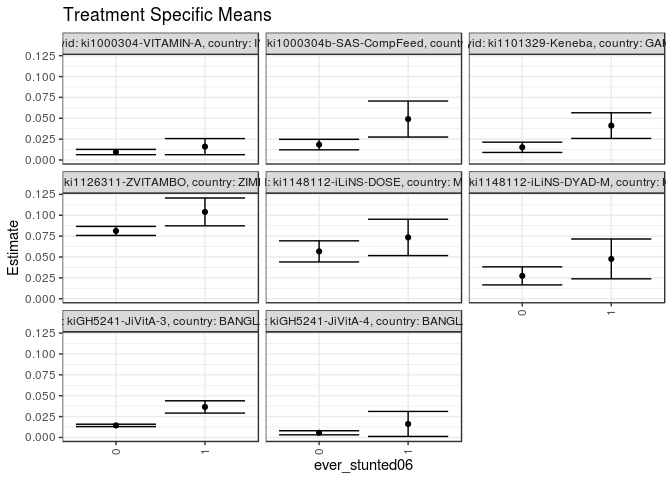

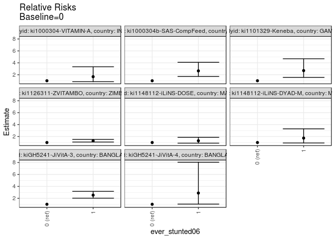

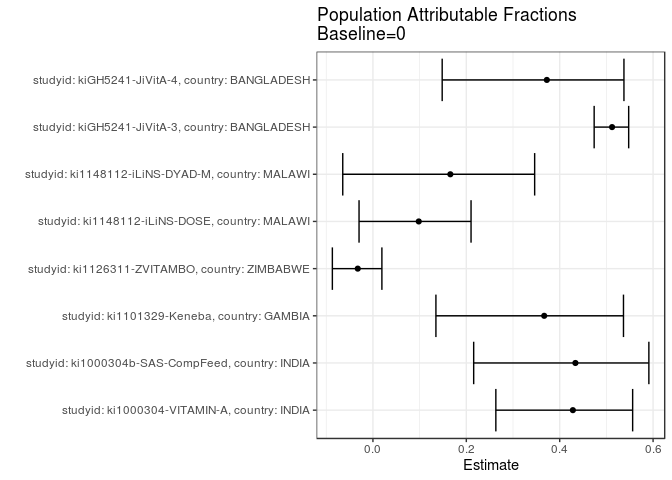

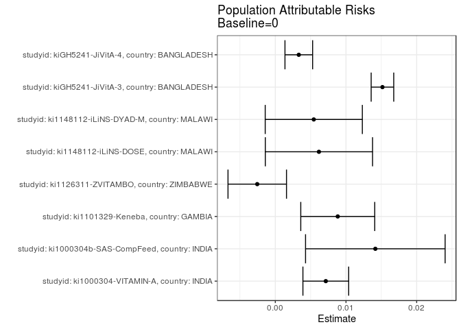

## Results Table

### Parameter: TSM

| studyid | country | intervention_level | baseline_level | estimate | ci_lower | ci_upper |
| --- | --- | --- | --- | --- | --- | --- |
| ki1000304-VITAMIN-A | INDIA | 0 | NA | 0.0095381 | 0.0063715 | 0.0127047 |
| ki1000304-VITAMIN-A | INDIA | 1 | NA | 0.0160243 | 0.0063720 | 0.0256767 |
| ki1000304b-SAS-CompFeed | INDIA | 0 | NA | 0.0184845 | 0.0122091 | 0.0247600 |
| ki1000304b-SAS-CompFeed | INDIA | 1 | NA | 0.0490713 | 0.0274805 | 0.0706620 |
| ki1101329-Keneba | GAMBIA | 0 | NA | 0.0152473 | 0.0090971 | 0.0213976 |
| ki1101329-Keneba | GAMBIA | 1 | NA | 0.0412277 | 0.0258337 | 0.0566217 |
| ki1126311-ZVITAMBO | ZIMBABWE | 0 | NA | 0.0812195 | 0.0757921 | 0.0866468 |
| ki1126311-ZVITAMBO | ZIMBABWE | 1 | NA | 0.1040182 | 0.0873575 | 0.1206789 |
| ki1148112-iLiNS-DOSE | MALAWI | 0 | NA | 0.0567080 | 0.0440693 | 0.0693466 |
| ki1148112-iLiNS-DOSE | MALAWI | 1 | NA | 0.0734648 | 0.0516779 | 0.0952517 |
| ki1148112-iLiNS-DYAD-M | MALAWI | 0 | NA | 0.0273852 | 0.0165567 | 0.0382138 |
| ki1148112-iLiNS-DYAD-M | MALAWI | 1 | NA | 0.0476915 | 0.0238162 | 0.0715668 |
| kiGH5241-JiVitA-3 | BANGLADESH | 0 | NA | 0.0144385 | 0.0130036 | 0.0158735 |
| kiGH5241-JiVitA-3 | BANGLADESH | 1 | NA | 0.0365478 | 0.0291739 | 0.0439218 |
| kiGH5241-JiVitA-4 | BANGLADESH | 0 | NA | 0.0055978 | 0.0031463 | 0.0080493 |
| kiGH5241-JiVitA-4 | BANGLADESH | 1 | NA | 0.0161571 | 0.0011599 | 0.0311543 |

### Parameter: E(Y)

| studyid | country | intervention_level | baseline_level | estimate | ci_lower | ci_upper |
| --- | --- | --- | --- | --- | --- | --- |
| ki1000304-VITAMIN-A | INDIA | NA | NA | 0.0166810 | 0.0124234 | 0.0209387 |
| ki1000304b-SAS-CompFeed | INDIA | NA | NA | 0.0326371 | 0.0205116 | 0.0447625 |
| ki1101329-Keneba | GAMBIA | NA | NA | 0.0240816 | 0.0180100 | 0.0301532 |
| ki1126311-ZVITAMBO | ZIMBABWE | NA | NA | 0.0786645 | 0.0742123 | 0.0831166 |
| ki1148112-iLiNS-DOSE | MALAWI | NA | NA | 0.0628792 | 0.0517023 | 0.0740561 |
| ki1148112-iLiNS-DYAD-M | MALAWI | NA | NA | 0.0328283 | 0.0226915 | 0.0429650 |
| kiGH5241-JiVitA-3 | BANGLADESH | NA | NA | 0.0295969 | 0.0274956 | 0.0316982 |
| kiGH5241-JiVitA-4 | BANGLADESH | NA | NA | 0.0089201 | 0.0062094 | 0.0116308 |

### Parameter: RR

| studyid | country | intervention_level | baseline_level | estimate | ci_lower | ci_upper |
| --- | --- | --- | --- | --- | --- | --- |
| ki1000304-VITAMIN-A | INDIA | 0 | 0 | 1.000000 | 1.0000000 | 1.000000 |
| ki1000304-VITAMIN-A | INDIA | 1 | 0 | 1.680027 | 0.8444194 | 3.342524 |
| ki1000304b-SAS-CompFeed | INDIA | 0 | 0 | 1.000000 | 1.0000000 | 1.000000 |
| ki1000304b-SAS-CompFeed | INDIA | 1 | 0 | 2.654717 | 1.7219491 | 4.092760 |
| ki1101329-Keneba | GAMBIA | 0 | 0 | 1.000000 | 1.0000000 | 1.000000 |
| ki1101329-Keneba | GAMBIA | 1 | 0 | 2.703929 | 1.5604101 | 4.685457 |
| ki1126311-ZVITAMBO | ZIMBABWE | 0 | 0 | 1.000000 | 1.0000000 | 1.000000 |
| ki1126311-ZVITAMBO | ZIMBABWE | 1 | 0 | 1.280706 | 1.0771009 | 1.522798 |
| ki1148112-iLiNS-DOSE | MALAWI | 0 | 0 | 1.000000 | 1.0000000 | 1.000000 |
| ki1148112-iLiNS-DOSE | MALAWI | 1 | 0 | 1.295494 | 0.8947511 | 1.875722 |
| ki1148112-iLiNS-DYAD-M | MALAWI | 0 | 0 | 1.000000 | 1.0000000 | 1.000000 |
| ki1148112-iLiNS-DYAD-M | MALAWI | 1 | 0 | 1.741504 | 0.9204305 | 3.295021 |
| kiGH5241-JiVitA-3 | BANGLADESH | 0 | 0 | 1.000000 | 1.0000000 | 1.000000 |
| kiGH5241-JiVitA-3 | BANGLADESH | 1 | 0 | 2.531274 | 2.0207928 | 3.170711 |
| kiGH5241-JiVitA-4 | BANGLADESH | 0 | 0 | 1.000000 | 1.0000000 | 1.000000 |
| kiGH5241-JiVitA-4 | BANGLADESH | 1 | 0 | 2.886330 | 1.0337932 | 8.058578 |

### Parameter: PAR

| studyid | country | intervention_level | baseline_level | estimate | ci_lower | ci_upper |
| --- | --- | --- | --- | --- | --- | --- |
| ki1000304-VITAMIN-A | INDIA | 0 | NA | 0.0071429 | 0.0039064 | 0.0103794 |
| ki1000304b-SAS-CompFeed | INDIA | 0 | NA | 0.0141525 | 0.0042779 | 0.0240271 |
| ki1101329-Keneba | GAMBIA | 0 | NA | 0.0088343 | 0.0036019 | 0.0140668 |
| ki1126311-ZVITAMBO | ZIMBABWE | 0 | NA | -0.0025550 | -0.0066936 | 0.0015837 |
| ki1148112-iLiNS-DOSE | MALAWI | 0 | NA | 0.0061712 | -0.0014166 | 0.0137591 |
| ki1148112-iLiNS-DYAD-M | MALAWI | 0 | NA | 0.0054430 | -0.0014285 | 0.0123146 |
| kiGH5241-JiVitA-3 | BANGLADESH | 0 | NA | 0.0151584 | 0.0135619 | 0.0167549 |
| kiGH5241-JiVitA-4 | BANGLADESH | 0 | NA | 0.0033223 | 0.0013662 | 0.0052784 |

### Parameter: PAF

| studyid | country | intervention_level | baseline_level | estimate | ci_lower | ci_upper |
| --- | --- | --- | --- | --- | --- | --- |
| ki1000304-VITAMIN-A | INDIA | 0 | NA | 0.4282051 | 0.2632518 | 0.5562264 |
| ki1000304b-SAS-CompFeed | INDIA | 0 | NA | 0.4336334 | 0.2157678 | 0.5909743 |
| ki1101329-Keneba | GAMBIA | 0 | NA | 0.3668486 | 0.1349100 | 0.5366024 |
| ki1126311-ZVITAMBO | ZIMBABWE | 0 | NA | -0.0324794 | -0.0868802 | 0.0191984 |
| ki1148112-iLiNS-DOSE | MALAWI | 0 | NA | 0.0981443 | -0.0297356 | 0.2101431 |
| ki1148112-iLiNS-DYAD-M | MALAWI | 0 | NA | 0.1658032 | -0.0646334 | 0.3463625 |
| kiGH5241-JiVitA-3 | BANGLADESH | 0 | NA | 0.5121614 | 0.4737967 | 0.5477290 |
| kiGH5241-JiVitA-4 | BANGLADESH | 0 | NA | 0.3724509 | 0.1483285 | 0.5375942 |